# Martin Week 5

These exercises follow the notes available here:

https://github.com/mjfrigaard/csuc-data-journalism/blob/main/notes/03-intro-to-ggplot2.pdf

## Install packages

Put the code from `00-inst.R` below:

```r
# install.packages(c("tidyverse", "janitor", "skimr", "fs", "ggthemes"))
library(tidyverse)
library(janitor)
library(skimr)
library(fs)
library(ggthemes)
```

## Import data

Put the code from `01.import.R` below:

```r
# create data folder
fs::dir_create("data/")
# create 'data/raw/' folder
fs::dir_create("data/raw/")

# data urls
balance_url <- "https://bit.ly/3hRzrKS"
brexit_url <- "https://bit.ly/3s2wqMx"
corbyn_url <- "https://bit.ly/35mgYRB"
pensions_url <- "https://bit.ly/2MNAvEp"

# data destination file paths
balance_destfile <- "data/raw/Balance.csv"
brexit_destfile <- "data/raw/Brexit.csv"
corbyn_destfile <- "data/raw/Corbyn.csv"
pensions_destfile <- "data/raw/Pensions.csv"

# download the files using the url and destfile
download.file(url = balance_url, destfile = balance_destfile)
download.file(url = brexit_url, destfile = brexit_destfile)
download.file(url = corbyn_url, destfile = corbyn_destfile)
download.file(url = pensions_url, destfile = pensions_destfile)

# import data
Balance <- readr::read_csv(balance_destfile)
Brexit <- readr::read_csv(brexit_destfile)
Corbyn <- readr::read_csv(corbyn_destfile)
Pensions <- readr::read_csv(pensions_destfile)
```

## Plot a histogram of average facebook likes with `qplot()`

Use the `Corbyn` dataset to view the `avg_facebook_likes` variable.

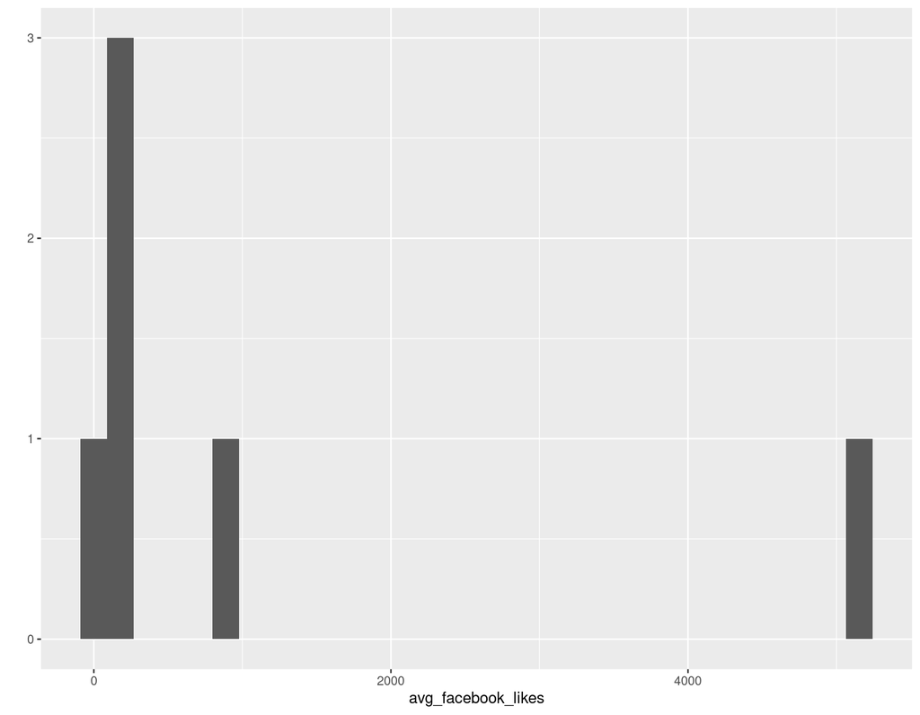

```r
Corbyn %>%
  ggplot2::qplot(x = avg_facebook_likes, data = .)
```

## Plot a box-plot of `pop_65_percent`

Use `qplot()` to graph the `pop_65_percent` variable from the `Pensions` dataset:

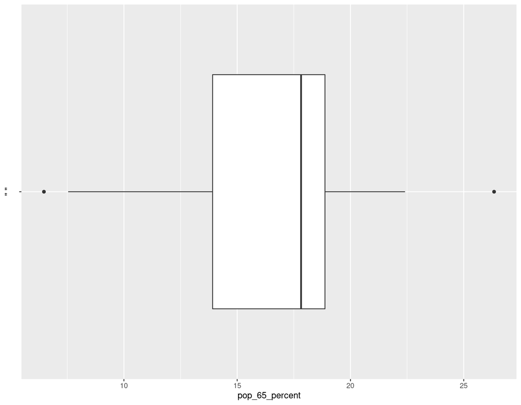

```r
Pensions %>%
  # the variable
  ggplot2::qplot(
    x = pop_65_percent,
    y = " ",
    data = .,
    geom = "boxplot"
  )
```

## Create a box-plot of `value` and `country`

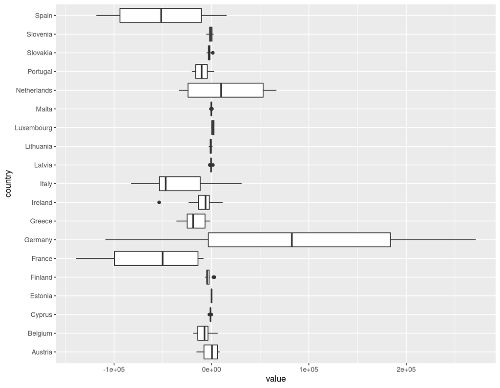

```r
Balance %>%
  ggplot2::qplot(
    x = value,
    y = country,
    data = .,
    geom = "boxplot"
  )
```

## Wrangle `date` variable in Brexit

Format the `date` variable in the `Brexit` dataset with `lubridate::dmy()`

```r
Brexit <- Brexit %>% mutate(date = lubridate::dmy(date))
glimpse(Brexit)
```

```
## Rows: 85
## Columns: 3
## $ date                     <date> 2016-08-02, 2016-08-09, 2016-08-17, 2016-08-…
## $ percent_responding_right <dbl> 46, 45, 46, 45, 47, 46, 45, 45, 46, 44, 44, 4…
## $ percent_responding_wrong <dbl> 42, 44, 43, 43, 44, 43, 44, 44, 43, 45, 42, 4…
```

## Create a scatter-plot of `date` and `percent_responding_right`

Use the `Brexit` dataset to plot date (on the x) and `percent_responding_right` (on the `y`)

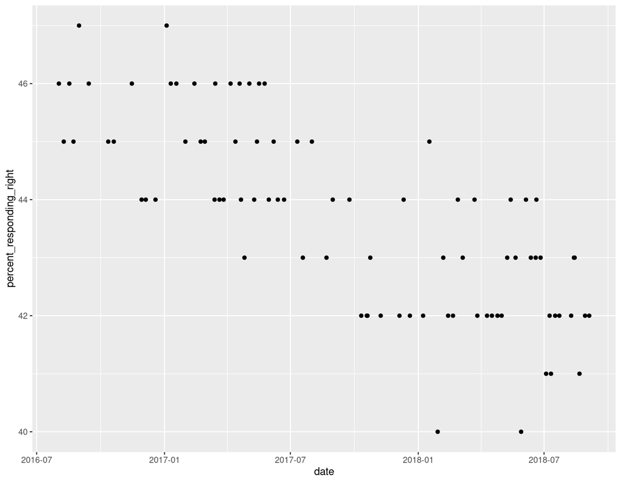

```r
Brexit %>%
  qplot(
    x = date,
    y = percent_responding_right, data = .
  )
```

## Build plots layer-by-layer with `ggplot()`

Run the code below to see how `tidyr::pivot_longer()` works.

```r
Brexit
```

| date | percent_responding_right | percent_responding_wrong |
| --- | --- | --- |
| 2016-08-02 | 46 | 42 |
| 2016-08-09 | 45 | 44 |
| 2016-08-17 | 46 | 43 |
| 2016-08-23 | 45 | 43 |
| 2016-08-31 | 47 | 44 |
| 2016-09-14 | 46 | 43 |
| 2016-10-12 | 45 | 44 |
| 2016-10-20 | 45 | 44 |
| 2016-11-15 | 46 | 43 |
| 2016-11-29 | 44 | 45 |

[output cut: 75 more lines]

```r
Brexit %>%
  tidyr::pivot_longer(
    cols = -date,
    names_to = "poll",
    values_to = "percent"
  )
```

| date | poll | percent |
| --- | --- | --- |
| 2016-08-02 | percent_responding_right | 46 |
| 2016-08-02 | percent_responding_wrong | 42 |
| 2016-08-09 | percent_responding_right | 45 |
| 2016-08-09 | percent_responding_wrong | 44 |
| 2016-08-17 | percent_responding_right | 46 |
| 2016-08-17 | percent_responding_wrong | 43 |
| 2016-08-23 | percent_responding_right | 45 |
| 2016-08-23 | percent_responding_wrong | 43 |
| 2016-08-31 | percent_responding_right | 47 |
| 2016-08-31 | percent_responding_wrong | 44 |

[output cut: 160 more lines]

Now pass the pivoted data to `qplot()` and view the result.

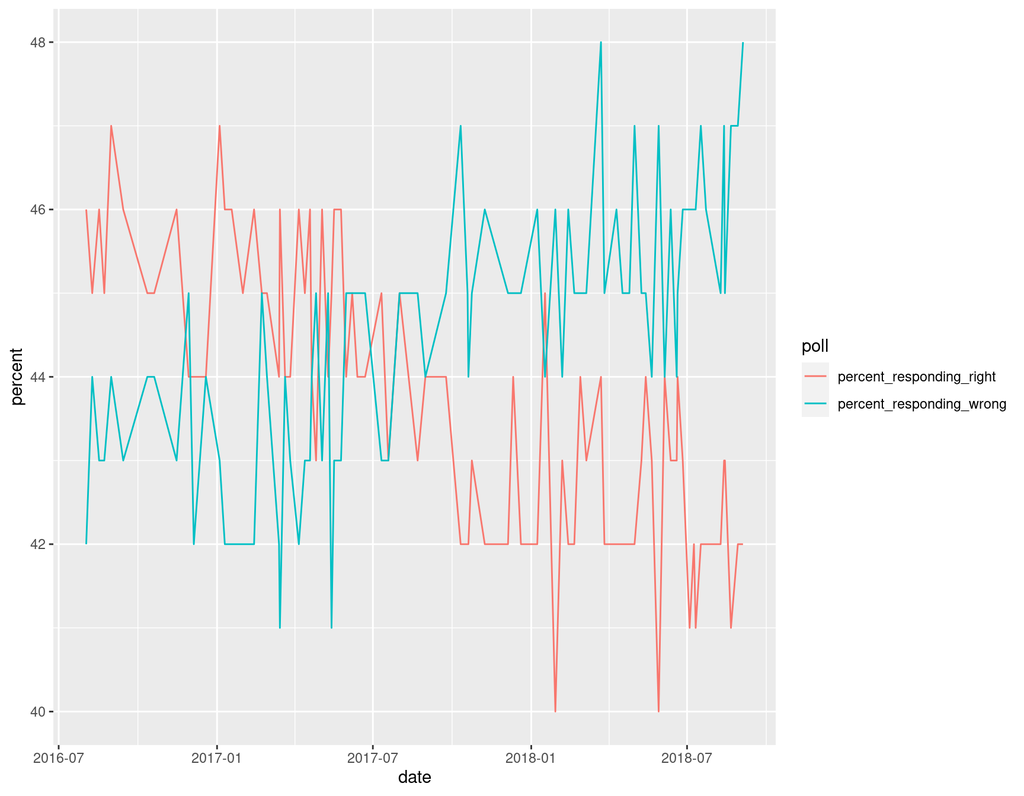

```r
Brexit %>%
  pivot_longer(
    cols = -date,
    names_to = "poll",
    values_to = "percent"
  ) %>%
  ggplot2::qplot(
    x = date,
    y = percent,
    group = poll,
    data = .,
    geom = "line",
    color = poll
  )
```

Wrangle the `Brexit` data below:

Assign the `tidyr::pivot_longer()` output to `TidyBrexit`

```r
TidyBrexit <- Brexit %>%
  pivot_longer(-date,
    names_to = "poll",
    values_to = "percent"
  )
head(TidyBrexit)
```

| date | poll | percent |
| --- | --- | --- |
| 2016-08-02 | percent_responding_right | 46 |
| 2016-08-02 | percent_responding_wrong | 42 |
| 2016-08-09 | percent_responding_right | 45 |
| 2016-08-09 | percent_responding_wrong | 44 |
| 2016-08-17 | percent_responding_right | 46 |
| 2016-08-17 | percent_responding_wrong | 43 |

## Map variables to aesthetics

Use the `TidyBrexit` data.frame to build the `ggp_brexit` plot object layer.

## Add the geom

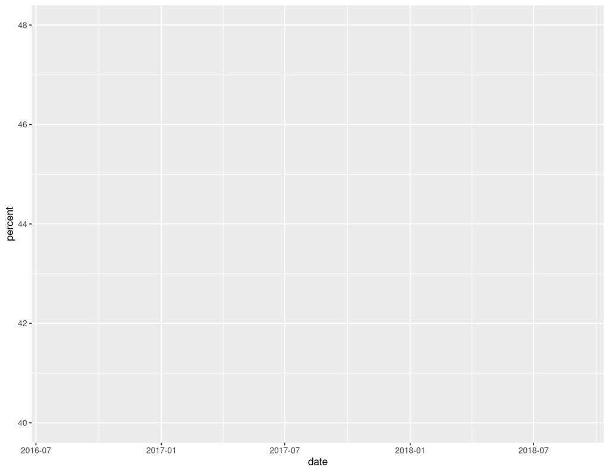

```r
ggp_brexit <- TidyBrexit %>%
  ggplot(mapping = aes(x = date, y = percent))
ggp_brexit
```

## Add the color aethetic to `poll`

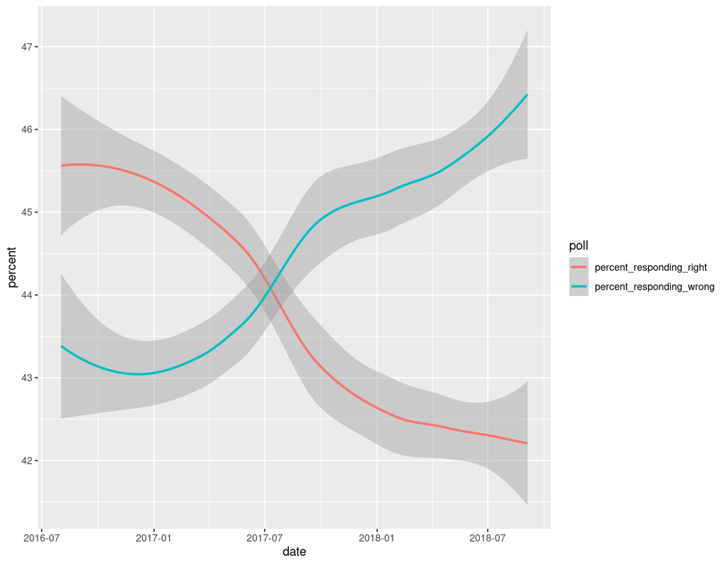

```r
ggp_brexit + ggplot2::geom_smooth(aes(color = poll))
```

Add the `se = FALSE` and `show.legend = FALSE` and create the `ggp_brexit_smooth` object.

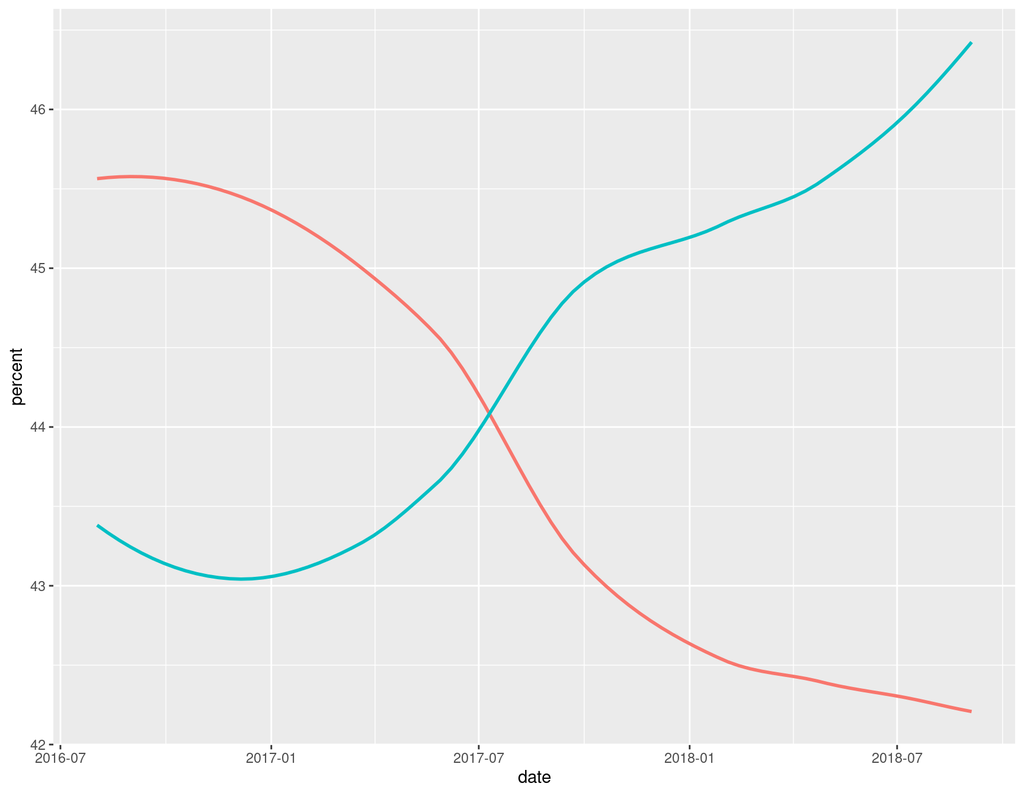

```r
ggp_brexit_smooth <- ggp_brexit +
  geom_smooth(aes(color = poll), se = FALSE, show.legend = FALSE)
ggp_brexit_smooth
```

## Add the points with `ggplot2::geom_point()`

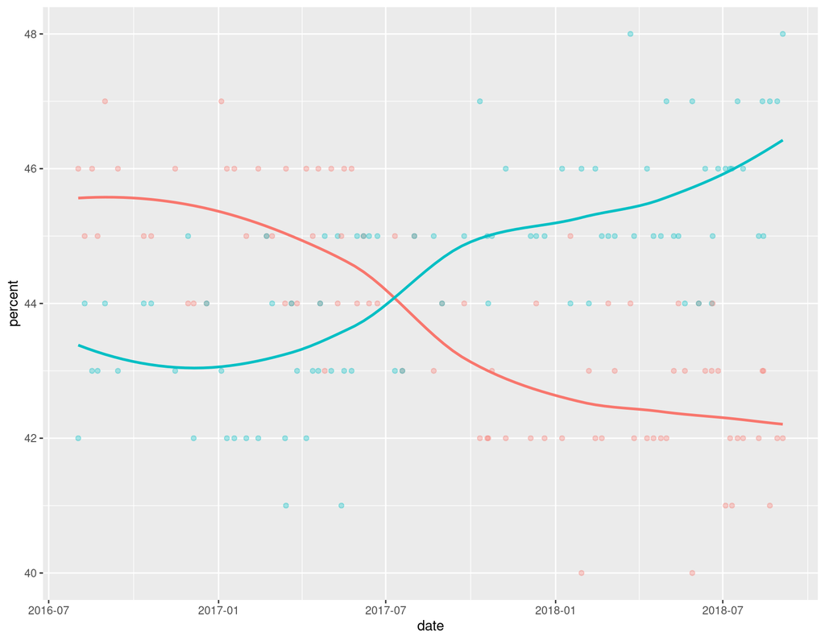

```r
ggp_brexit_smooth +
  geom_point(aes(color = poll), show.legend = FALSE, alpha = 1 / 3)
```

## Set the aesthetics globally

Rebuild the plot with the `TidyBrexit` dataset, mapping `date`, `percent`, and `poll` globally.

- add the `ggplot2::geom_smooth()` layer with the `se = FALSE` and `show.legend = FALSE`
- add the `ggplot2::geom_point()` layer with `alpha = 1/3` and `show.legend = FALSE`

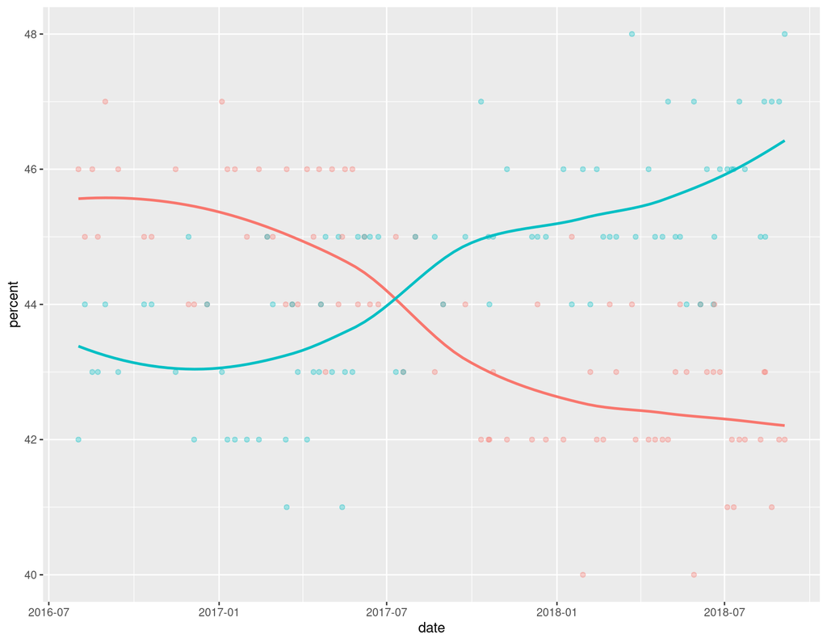

```r
ggp_brexit_global <- TidyBrexit %>%
  ggplot(mapping = aes(x = date, y = percent, color = poll)) +
  geom_smooth(se = FALSE, show.legend = FALSE) +
  geom_point(alpha = 1 / 3, show.legend = FALSE)
ggp_brexit_global
```

## Add colors

Add the colors `cornflowerblue` and `firebrick3` to the `ggp_brexit_global` layer and create a new layer called `ggp_brexit_global_colors`.

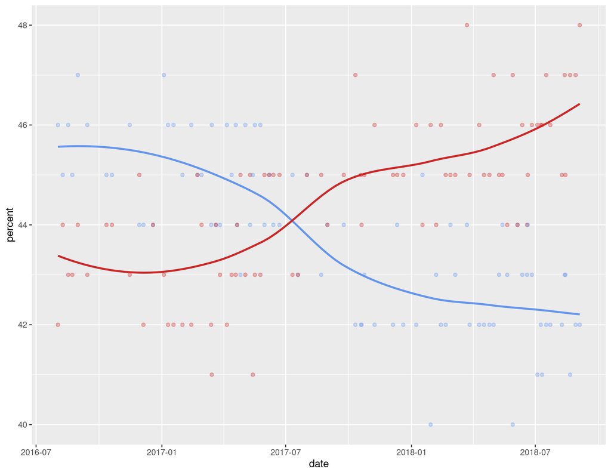

```r
ggp_brexit_global_colors <- ggp_brexit_global +
  scale_color_manual(values = c("cornflowerblue", "firebrick3"))
ggp_brexit_global_colors
```

## Add text

Use the ggplot2::geom_text() layer to add the text to the `ggp_brexit_global_colors` layer, and name the new plot `ggp_brexit_global_colors_text`

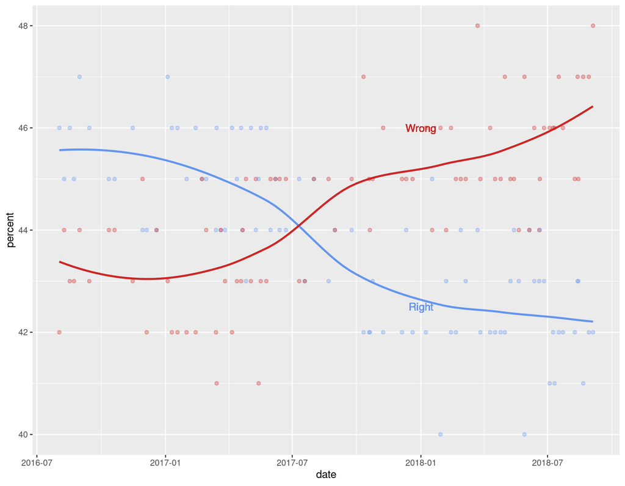

```r
ggp_brexit_global_colors_text <- ggp_brexit_global_colors +
  geom_text(
    label = "Wrong", color = "firebrick3",
    x = as.Date("2018-01-01"), y = 46
  ) +
  geom_text(
    label = "Right", color = "cornflowerblue",
    x = as.Date("2018-01-01"), y = 42.5
  )
ggp_brexit_global_colors_text
```

## Move the `y` axis

Move the y axis to the right side of the graph with `ggplot2::scale_y_continuous()`

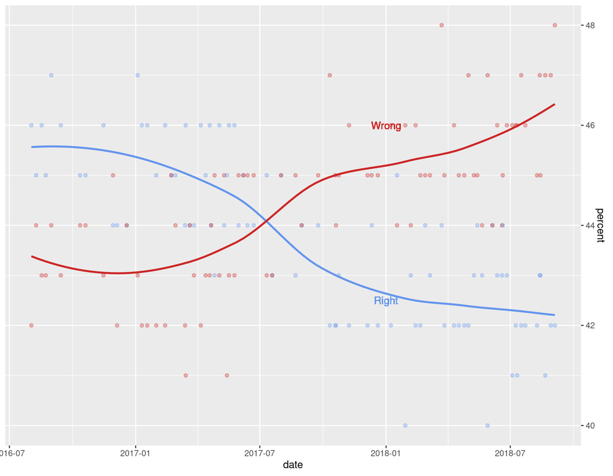

```r
ggp_brexit_global_colors_text_scale_y <- ggp_brexit_global_colors_text +
  ggplot2::scale_y_continuous(position = "right")
ggp_brexit_global_colors_text_scale_y
```

## Add labels

Use the `ggplot2::labs()` function to create the labels layer.

```r
labs_eco <- ggplot2::labs(
  title = "Bremorse",
  subtitle = "'In hindsight, do you think Britain was right or wrong to vote to leave the EU?'",
  caption = "Source: NatCen Social Research",
  x = " ",
  y = "Percent (%)"
)
```

Add the labels layer to `ggp_brexit_global_colors_text_scale_y` and create a new plot titled, `ggp_brexit_labs`.

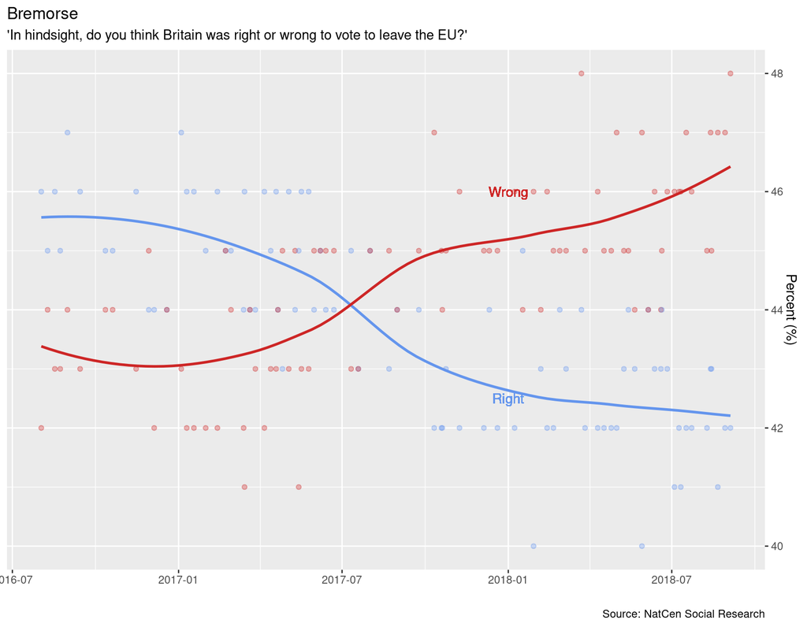

```r
ggp_brexit_labs <- ggp_brexit_global_colors_text_scale_y + labs_eco
ggp_brexit_labs
```

## Add theme

```r
# install.packages("ggthemes")
library(ggthemes)
```

Add the `ggthemes::theme_economist_white()` layer and set the following arguments:

- `gray_bg = FALSE`
- `base_size = 12`
- `base_family = "Verdana"`

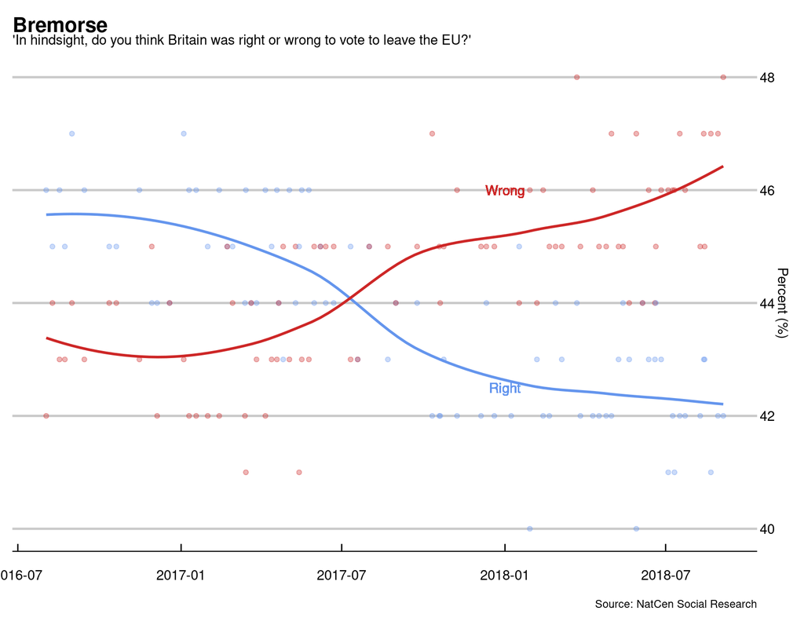

```r
ggp_brexit_labs +
  ggthemes::theme_economist_white(
    gray_bg = FALSE,
    base_size = 12,
    base_family = "Verdana"
  )
```